# L3-linear_regression_part_2

Error-Based Learning

Regression: part II

In this section, we cover the following concepts:

- performance evaluation of developed models;
- multi-feature regression;
- concepts of normalization and standardization;
- polynomial regression;
- feature selection process.

# Performance comparison

Let us recall some things from the previous section.

We have developed a model predicting the sales of a single product based on the investment into radio advertising. Now, we are going to determine how well our model behaves. From the original data points we create two separate sets: one to train a model, and one to test it.

## Training and testing datasets

```python
import pandas as pd
import numpy as np
import matplotlib.pyplot as plt
```

```python
import warnings; warnings.simplefilter('ignore')
```

```python
data = pd.read_csv('data/Advertising.csv')
X = data.loc[:,['radio']].values
Y = data['sales'].values.reshape(len(X),1)
```

```python
data.head()
```

|  | Unnamed: 0 | TV | radio | newspaper | sales |
| --- | --- | --- | --- | --- | --- |
| 0 | 1 | 230.1 | 37.8 | 69.2 | 22.1 |
| 1 | 2 | 44.5 | 39.3 | 45.1 | 10.4 |
| 2 | 3 | 17.2 | 45.9 | 69.3 | 9.3 |
| 3 | 4 | 151.5 | 41.3 | 58.5 | 18.5 |
| 4 | 5 | 180.8 | 10.8 | 58.4 | 12.9 |

We use `scikit-learn` to split the data into training and testing data.

`test_size=0.3` means \%30 of the data for testing.

```python
from sklearn.model_selection import train_test_split
X_train, X_test, Y_train, Y_test = train_test_split( X , Y , test_size = 0.3, random_state = 0)
```

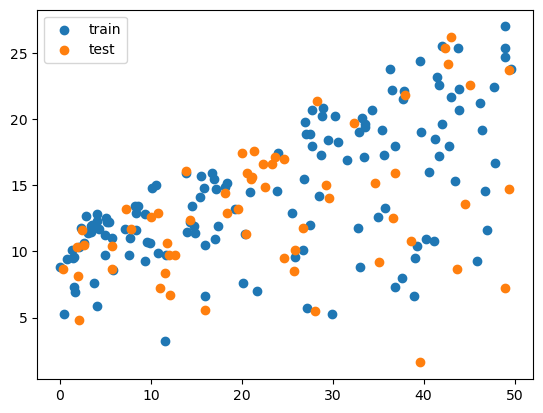

```python
plt.scatter(X_train,Y_train,label='train')
plt.scatter(X_test,Y_test, label='test')
plt.legend();
```

We use our previously created functions for linear regression.

```python
import sys
sys.path.append('scripts')
```

```python
import linear_regression as linreg
```

```python
w, h, w_h = linreg.train(X_train,Y_train, 0.001, 20000)
```

```
iter	 Cost 		 Weights
0	23.328872	[[0.03706245 0.41853941]]
2000	11.982198	[[4.2457959  0.36781512]]
4000	9.225654	[[6.55889133 0.29824865]]
6000	8.3921269	[[7.83084395 0.25999461]]
8000	8.140084	[[8.5302805  0.23895902]]
10000	8.0638709	[[8.91489505 0.22739172]]
12000	8.0408256	[[9.1263915  0.22103095]]
14000	8.0338571	[[9.2426917  0.21753321]]
16000	8.0317499	[[9.30664425 0.21560984]]
18000	8.0311128	[[9.34181125 0.21455219]]
```

```python
w
```

```
array([[9.36114223],
       [0.21397081]])
```

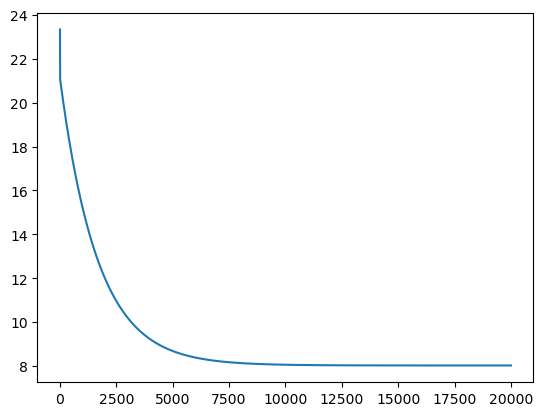

```python
plt.plot(h)
```

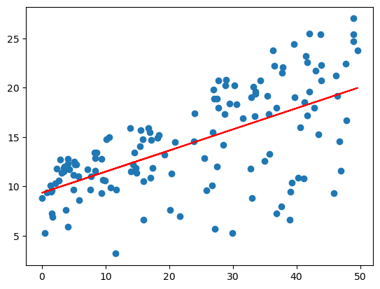

```python
plt.scatter(X_train,Y_train)
plt.plot(X_train, w[0]+w[1]*X_train, 'r');
```

Now we plot out predictions against the testing data. We obtain the following:

```python
bias = np.ones(shape=(len(X_test),1))
Features = np.append(bias, X_test, axis=1)
Y_pred = linreg.predict(Features,w)
```

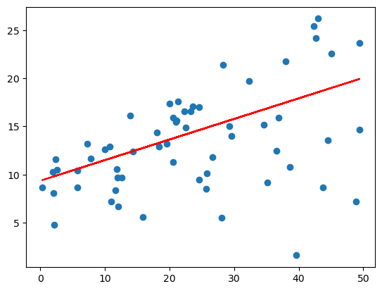

```python
plt.scatter(X_test , Y_test)
plt.plot(X_test , Y_pred, 'r');
```

If we compare the cost function values obtained using the training data (`cost_train`) with the testing data (`cost_test`), we can observe a higher cost function value for the testing data. In general, it is normal behaviour. The model is 'learned' based on the training data and 'better suited' to predict if it is exposed to already seen training data than to new, unseen testing data.

```python
cost_train =  h[-1] # last cost
cost_test = linreg.cost_function(Features, Y_test, w)
cost_train, cost_test
```

```
(8.03092015276882, 11.63022644035576)
```

## Model development using scikit

Now, let us train the model using `scikit-learn`.

```python
from sklearn import linear_model
```

```python
sklreg = linear_model.LinearRegression()
```

```python
sklreg.fit(X_train,Y_train)
```

```
LinearRegression()
```

```python
wsk = np.array([sklreg.intercept_,sklreg.coef_[0]])
```

```python
wsk
```

```
array([[9.38477437],
       [0.21326007]])
```

```python
Y_pred_sk = sklreg.predict(X_test)
```

A visual comparison between the model developed using our one function, and the model developed using scikit-learn is not easy. It is difficult to determine which model makes better predictions.

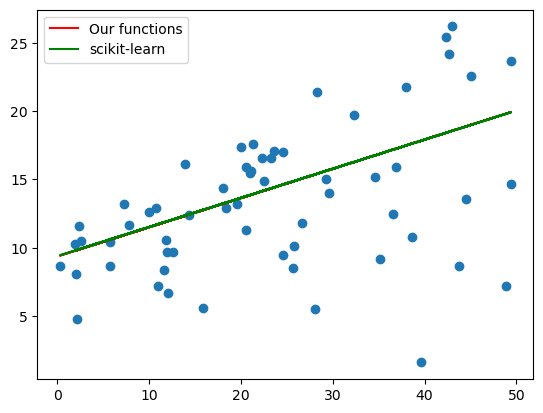

```python
plt.scatter(X_test , Y_test)
plt.plot(X_test , Y_pred, 'r', label='Our functions')
plt.plot(X_test , Y_pred_sk, 'g', label='scikit-learn');
plt.legend();
```

```python
cost_test_sk = linreg.cost_function(Features, Y_test, wsk)
cost_test_sk
```

```
11.632214419870207
```

We use the *score* to compare both models.

```python
score_train_sk = sklreg.score(X_train,Y_train)
score_test_sk = sklreg.score(X_test,Y_test)
score_train_sk, score_test_sk
```

```
(0.39648649461739327, 0.148565655419297)
```

Now, we build our own *score* function.

```python
def score(X, Y, w):
    bias = np.ones(shape=(len(X),1))
    Features = np.append(bias, X, axis=1)
    Y_pred = linreg.predict(Features,w)
    u = ((Y - Y_pred) ** 2).sum()
    v = ((Y - Y.mean()) ** 2).sum()
    return 1-u/v
```

```python
score_train = score(X_train, Y_train, w)
score_test = score(X_test, Y_test, w)
score_train, score_test
```

```
(0.3964802151090988, 0.14871116804258855)
```

```python
import pandas as pd
pd.DataFrame({'Implementation':['ours','scikit-learn'],
              'Train cost':[score_train,score_train_sk],
              'Test cost':[score_test,score_test_sk]})
```

|  | Implementation | Train cost | Test cost |
| --- | --- | --- | --- |
| 0 | ours | 0.396480 | 0.148711 |
| 1 | scikit-learn | 0.396486 | 0.148566 |

## Exercise

✏️ Compare the quality of predictions obtained with your linear regression model and the model developed using scikit-learn. The models should predict the sales based on the TV and newspaper investments (data/Advertising.csv).

# Multi-feature linear regression

## Model development (two features)

So far, we have developed a regression model based on data with only one feature. However in most cases, we have data that has more than one feature as dependent variables.

In these cases, we use the same method for computing a linear regression, but change the way the hypothesis is expressed. Now, the hypotthesis is represented as a linear combination:

$$ h_\theta(X) = \theta_0 + \theta_1x_1+\theta_2x_2+\theta_3x_3+... $$

The same predictor function (matrix version), as defined previously, can be used to represent the multi-feature hypothesis.

$$ \theta = \left[ \begin{matrix} \theta_0 & \theta_1 & ... & \theta_n \end{matrix} \right]^T $$$$ X = \left[ \begin{matrix} 1 & x_{1_1} & ... & x_{n_1} \\ 1 & x_{1_2} & ... & x_{n_2} \\ \vdots & \vdots & & \vdots \\ 1 & x_{1_m} & ... & x_{n_m} \\ \end{matrix} \right] $$

```python
def predictor(Features, Weights):
    return Features @ Weights # dot product
```

Let us go back to the problem of predicting how investments in radio and TV advertisments affect sales:

$$ h_\theta(radio,TV) = \theta_0 + \theta_1 radio + \theta_2 TV $$

```python
data = pd.read_csv('data/Advertising.csv')
X = data.loc[:,['radio','TV']].values
Y = data['sales'].values.reshape(len(X),1)
```

```python
from sklearn.model_selection import train_test_split
X_train, X_test, Y_train, Y_test = train_test_split( X , Y , test_size = 0.3, random_state = 0)
```

The plot of the training and testing data points looks like this:

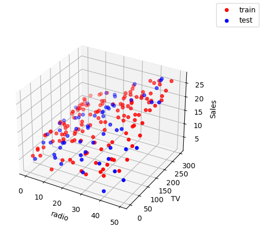

```python
from mpl_toolkits.mplot3d import Axes3D
fig = plt.figure()
ax = fig.add_subplot(111, projection='3d')
#ax.view_init(elev=10., azim=25)
ax.scatter(X_train[:,0], X_train[:,1], Y_train,c='r',label='train')
ax.scatter(X_test[:,0], X_test[:,1], Y_test,c='b',label='test')
ax.set_xlabel('radio')
ax.set_ylabel('TV')
ax.set_zlabel('Sales')
fig.legend();
```

We use our linear regression implementation.

```python
import linear_regression as linreg
```

```python
%time w, h, w_h = linreg.train(X_train,Y_train, 0.00001, 200000)
```

```
iter	 Cost 		 Weights
0	2359.4407	[[0.18344462 0.54414714 0.40751674]]
20000	1.7892652	[[0.26147661 0.23998086 0.05260225]]
40000	1.7563799	[[0.34256324 0.23878724 0.05233785]]
60000	1.7254775	[[0.42116725 0.23763016 0.05208155]]
80000	1.6964383	[[0.49736463 0.23650851 0.05183309]]
100000	1.6691502	[[0.57122908 0.2354212  0.05159224]]
120000	1.6435074	[[0.64283203 0.23436719 0.05135876]]
140000	1.6194108	[[0.71224271 0.23334544 0.05113243]]
160000	1.5967671	[[0.77952824 0.23235497 0.05091304]]
180000	1.5754888	[[0.84475369 0.23139483 0.05070035]]
CPU times: user 3.37 s, sys: 722 ms, total: 4.09 s
Wall time: 3.49 s
```

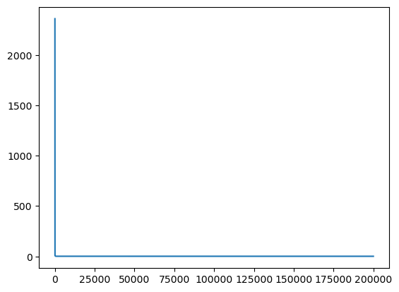

```python
plt.plot(h);
```

In the plot below, we can observe the hyperplane generated using the parameters from our trained model.

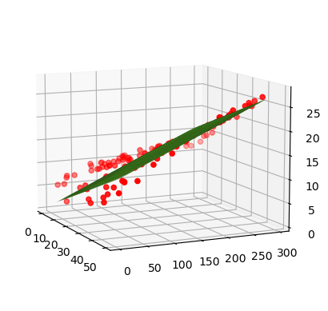

```python
from mpl_toolkits.mplot3d import Axes3D
fig = plt.figure()
ax = fig.add_subplot(111, projection='3d')
ax.view_init(elev=10., azim=-25) # -25
x1,x2 = np.meshgrid(X_train[:,0], X_train[:,1])
zp = w[0] + w[1]*x1 + w[2]*x2
ax.plot_surface(x1,x2,zp, color=[0.4,0.7,0.2,0.05])
ax.scatter(X_train[:,0], X_train[:,1], Y_train,c='r');
```

## Normalization

As we observed in the training process, it have taken more time and required a smaller learning rate. To speed up the gradiant descent in multi-feature regression, we could use data scaling methods. Two of these methods are *normalization* and *standardization*

**Normalization** (or min-max scaling) is defined as:

$$ X' = \frac{X-\min(X)}{\max(X)-\min(X)}, $$

where each value of $X'$ in in the range $[0,1]$

```python
def normalization(Features):
    """
    Take a set of features return normalize values using
    (x -xmin) / (xmax – xmin) of each feature
    """
    fmin = np.min(Features,axis=0)
    fmax = np.max(Features,axis=0)
    Features_norm = (Features - fmin)/(fmax-fmin)
    return Features_norm
```

```python
X_train
```

```
array([[  2.9, 265.2],
       [  3.5, 197.6],
       [  5.4, 218.5],
       [ 23.9, 147.3],
       [ 39.7, 171.3],
       [ 33.5, 217.7],
       [ 28.8, 262.7],
       [ 36.8, 163.5],
       [  9.6, 100.4],
       [ 27.5,  76.3],
       [ 43.9, 184.9],
       [  4.9, 134.3],
       [ 28.9, 273.7],
       [ 36.3, 296.4],
       [ 14.8,  96.2],
       [ 47.8, 109.8],
       [ 26.9, 255.4],
       [ 32.9, 204.1],
       [ 16.7, 240.1],
       [ 35.4, 193.7],
       [ 28.7, 191.1],
       [  9.9,  89.7],
       [ 25.9,  43. ],
       [  3.7,  38.2],
       [  0.4,  13.1],
       [ 15.5, 239.3],
       [ 45.9,  17.2],
       [ 29.5, 210.7],
       [ 39. ,  25.6],
       [  9.3, 177. ],
       [  8.4, 206.9],
       [  5.8,  66.1],
       [ 35.6, 149.7],
       [  5.7, 129.4],
       [  4.9,  94.2],
       [  2.3, 276.7],
       [ 48.9, 276.9],
       [ 38.9,   7.8],
       [ 36.5, 250.9],
       [ 15.4, 175.7],
```

[output cut: 85 more lines]

```
       [ 37.7, 228. ],
       [ 49.6, 210.8],
       [ 17. ,  73.4],
       [ 25.5,  88.3],
       [ 30.6, 199.1],
       [ 40.6, 110.7],
       [ 43.8, 266.9],
       [  5.1, 237.4],
       [  2.6, 199.8],
       [ 17.2, 187.9],
       [ 14.5, 139.3],
       [  4.1,  17.2],
       [  0.8,  76.4],
       [ 41.5, 239.9],
       [ 20.1,  19.6]])
```

```python
X_train_norm = normalization(X_train)
```

```python
X_train_norm
```

```
array([[0.05846774, 0.89326035],
       [0.07056452, 0.66199111],
       [0.10887097, 0.73349299],
       [0.48185484, 0.48990763],
       [0.80040323, 0.57201505],
       [0.67540323, 0.73075607],
       [0.58064516, 0.88470749],
       [0.74193548, 0.54533014],
       [0.19354839, 0.32945604],
       [0.55443548, 0.2470065 ],
       [0.88508065, 0.61854259],
       [0.09879032, 0.44543277],
       [0.58266129, 0.92234006],
       [0.73185484, 1.        ],
       [0.2983871 , 0.31508724],
       [0.96370968, 0.36161478],
       [0.54233871, 0.85973315],
       [0.66330645, 0.68422853],
       [0.33669355, 0.80738967],
       [0.71370968, 0.64864865],
       [0.57862903, 0.63975368],
       [0.19959677, 0.29284981],
       [0.52217742, 0.13308245],
       [0.07459677, 0.11666096],
       [0.00806452, 0.03079028],
       [0.3125    , 0.80465275],
       [0.92540323, 0.04481697],
       [0.59475806, 0.70680807],
       [0.78629032, 0.07355457],
       [0.1875    , 0.59151557],
       [0.16935484, 0.69380773],
       [0.11693548, 0.21211085],
       [0.71774194, 0.49811837],
       [0.11491935, 0.42866918],
       [0.09879032, 0.30824495],
       [0.04637097, 0.93260349],
       [0.9858871 , 0.93328772],
       [0.78427419, 0.01265823],
       [0.7358871 , 0.84433801],
       [0.31048387, 0.58706808],
```

[output cut: 85 more lines]

```
       [0.76008065, 0.76599384],
       [1.        , 0.70715019],
       [0.34274194, 0.23708519],
       [0.5141129 , 0.28806021],
       [0.61693548, 0.66712282],
       [0.81854839, 0.36469381],
       [0.88306452, 0.89907629],
       [0.10282258, 0.79815258],
       [0.05241935, 0.66951762],
       [0.34677419, 0.62880602],
       [0.29233871, 0.46253849],
       [0.08266129, 0.04481697],
       [0.01612903, 0.24734861],
       [0.83669355, 0.80670544],
       [0.40524194, 0.05302771]])
```

After normaliztion, training of the model is faster.

```python
%time w_n, h_n, w_h_n = linreg.train(X_train_norm,Y_train, 0.001, 30000)
```

```
iter	 Cost 		 Weights
0	93.948577	[[0.92940244 0.36220912 0.88734657]]
3000	3.8227311	[[8.46493015 5.6198086  6.71862338]]
6000	3.0334855	[[7.65007976 6.42170663 7.73710735]]
9000	2.4909882	[[6.89543417 7.04289048 8.55426081]]
12000	2.1131628	[[6.26534736 7.55307082 9.24210671]]
15000	1.8499355	[[5.73984317 7.97281009 9.82109303]]
18000	1.6664947	[[ 5.30151179  8.31846371 10.30816195]]
21000	1.5386246	[[ 4.9358477   8.60335904 10.71768319]]
24000	1.4494719	[[ 4.63076913  8.83837305 11.06183214]]
27000	1.3873021	[[ 4.37621085  9.03239383 11.35091261]]
CPU times: user 514 ms, sys: 118 ms, total: 632 ms
Wall time: 531 ms
```

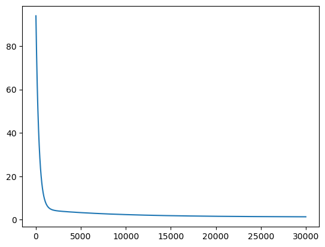

```python
plt.plot(h_n);
```

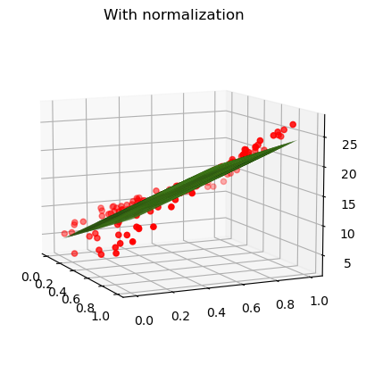

```python
from mpl_toolkits.mplot3d import Axes3D
fig = plt.figure()
ax = fig.add_subplot(111, projection='3d')
ax.view_init(elev=10., azim=-25)
x1,x2 = np.meshgrid(X_train_norm[:,0], X_train_norm[:,1])
zp = w_n[0] + w_n[1]*x1 + w_n[2]*x2
ax.plot_surface(x1,x2,zp, color=[0.4,0.7,0.2,0.05])
ax.scatter(X_train_norm[:,0], X_train_norm[:,1], Y_train,c='r');
ax.set_title("With normalization");
```

## Standardization

$$ X' = \frac{X-\mu(X)}{\sigma(X)}, $$

where $\mu(X')=0$ and $\sigma(X')=1$ ($\mu$: mean, $\sigma$: standard deviation)

```python
def standardization(Features):
    """
    Take a set of features return normalize values using
    the mean and standard deviation of each feature
    """
    mean=np.mean(Features,axis=0)
    std=np.std(Features,axis=0)
    Features_zss = (Features - mean)/std
    return Features_zss
```

```python
X_train_std = standardization(X_train)
```

```python
%time w_s, h_s, w_h_s = linreg.train(X_train_std, Y_train, 0.001, 30000)
```

```
iter	 Cost 		 Weights
0	99.857931	[[0.84221526 0.61288741 0.87484718]]
3000	1.4828925	[[13.6839259   2.9597754   3.56607881]]
6000	1.2444549	[[14.32231808  3.05737168  3.68360481]]
9000	1.2438741	[[14.35405408  3.06138769  3.68877429]]
12000	1.2438727	[[14.35563175  3.06155041  3.68900378]]
15000	1.2438727	[[14.35571018  3.06155686  3.68901408]]
18000	1.2438727	[[14.35571408  3.0615571   3.68901455]]
21000	1.2438727	[[14.35571428  3.06155711  3.68901457]]
24000	1.2438727	[[14.35571429  3.06155711  3.68901457]]
27000	1.2438727	[[14.35571429  3.06155711  3.68901457]]
CPU times: user 520 ms, sys: 122 ms, total: 642 ms
Wall time: 539 ms
```

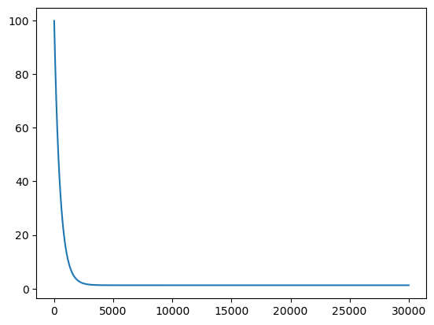

```python
plt.plot(h_s);
```

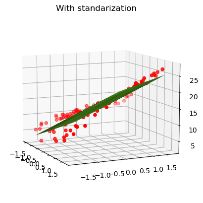

```python
from mpl_toolkits.mplot3d import Axes3D
fig = plt.figure()
ax = fig.add_subplot(111, projection='3d')
ax.view_init(elev=10., azim=-25) #-25
x1,x2 = np.meshgrid(X_train_std[:,0], X_train_std[:,1])
zp = w_s[0] + w_s[1]*x1 + w_s[2]*x2
ax.plot_surface(x1,x2,zp, color=[0.4,0.7,0.2,0.05])
ax.scatter(X_train_std[:,0], X_train_std[:,1], Y_train,c='r');
ax.set_title("With standarization");
```

## Model development with scikit-learn

Let us create a model using `scikit-learn`.

```python
sklreg = linear_model.LinearRegression()
```

To perform data normalization with `scikit-learn`, we use `MinMaxScaler`.

```python
# With normalization
from sklearn.preprocessing import MinMaxScaler
scaler = MinMaxScaler()

X_train_norm = scaler.fit_transform(X_train)
X_test_norm = scaler.transform(X_test)
```

```python
sklreg.fit(X_train_norm,Y_train)
```

```
LinearRegression()
```

```python
wsk = [sklreg.intercept_[0],sklreg.coef_[0][0],sklreg.coef_[0][1]]
```

```python
wsk
```

```
[3.0901584076576594, 9.96936494863359, 12.851412736927632]
```

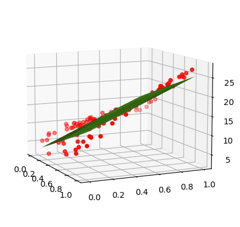

```python
fig = plt.figure()
ax = fig.add_subplot(111, projection='3d')
ax.view_init(elev=10., azim=-25)
x1,x2 = np.meshgrid(X_train_norm[:,0], X_train_norm[:,1])
zp = wsk[0] + wsk[1]*x1 + wsk[2]*x2
ax.plot_surface(x1,x2,zp, color=[0.4,0.7,0.2,0.05])
ax.scatter(X_train_norm[:,0], X_train_norm[:,1], Y_train,c='r');
```

To do data standardization, we need to import and create an instance of `StandardScaler` from `sklearn.preprocessing` and transform the features.

```python
# Using Standardization
from sklearn.preprocessing import StandardScaler
#X_train_scaled = StandardScaler().fit_transform(X_train)

# Initialize the StandardScaler
scaler = StandardScaler()

# Fit the scaler to the training data and transform
X_train_scaled = scaler.fit_transform(X_train)
X_test_scaled = scaler.transform(X_test)
```

```python
 sklreg.fit(X_train_scaled, Y_train)
```

```
LinearRegression()
```

```python
wsk = [sklreg.intercept_[0],sklreg.coef_[0][0],sklreg.coef_[0][1]]
```

```python
wsk
```

```
[14.355714285714285, 3.0615571099048613, 3.689014573504892]
```

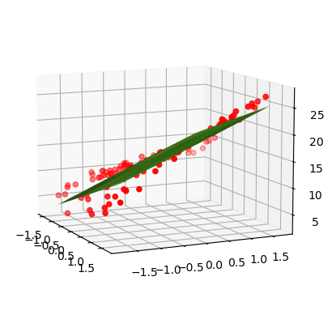

```python
fig = plt.figure()
ax = fig.add_subplot(111, projection='3d')
ax.view_init(elev=10., azim=-25)
x1,x2 = np.meshgrid(X_train_scaled[:,0], X_train_scaled[:,1])
zp = wsk[0] + wsk[1]*x1 + wsk[2]*x2
ax.plot_surface(x1,x2,zp, color=[0.4,0.7,0.2,0.05])
ax.scatter(X_train_scaled[:,0], X_train_scaled[:,1], Y_train,c='r');
```

```python
bias = np.ones(shape=(len(X_test_scaled),1))
Features = np.append(bias, X_test_scaled, axis=1)
Y_pred = linreg.predict(Features,wsk)
```

```python
Y_pred_sk = sklreg.predict(X_test_scaled)
```

## Performance comparison

Let us compare the performance of all obtained results using the *score*.

```python
import pandas as pd
pd.DataFrame({'':['Widthout normalization','With normalization','With standarization','scikit-learn'],
              'Train score':[score(X_train, Y_train, w),
                             score(X_train_norm, Y_train, w_n),
                             score(X_train_std, Y_train, w_s),
                             sklreg.score(X_train_scaled,Y_train)],
              'Test score':[score(X_test, Y_test, w),
                            score(normalization(X_test), Y_test, w_n),
                            score(standardization(X_test), Y_test, w_s),
                            sklreg.score(X_test_scaled,Y_test)]})
```

|  |  | Train score | Test score |
| --- | --- | --- | --- |
| 0 | Widthout normalization | 0.883105 | 0.841052 |
| 1 | With normalization | 0.899003 | 0.850679 |
| 2 | With standarization | 0.906524 | 0.797501 |
| 3 | scikit-learn | 0.906524 | 0.865655 |

## Exercise

✏️ Compare the quality of predictions obtained using our linear regression implementation and the one obtained using `scikit-learn`, by predicting the sales using pair-wise combinations of radio, TV and newspaper investments, i.e., radio and newspaper, TV and newspaper, TV and newspaper. Compare how the performance changes if normalization and standardization are used.

## Model development (three features)

Now we want to know how radio, TV and newspaper all together affect the sales. In this case, our hypothesis function changes to the following:

$$ h_\theta(radio,TV,newspaper) = \theta_0 + \theta_1 radio + \theta_2 TV + \theta_3 newspaper $$

```python
data = pd.read_csv('data/Advertising.csv')
X = data.loc[:,['radio','TV','newspaper']].values
Y = data['sales'].values.reshape(len(X),1)
```

Again, we create training and testing sets from the given data points.

```python
from sklearn.model_selection import train_test_split
X_train, X_test, Y_train, Y_test = train_test_split( X , Y , test_size = 0.2, random_state = 0)
```

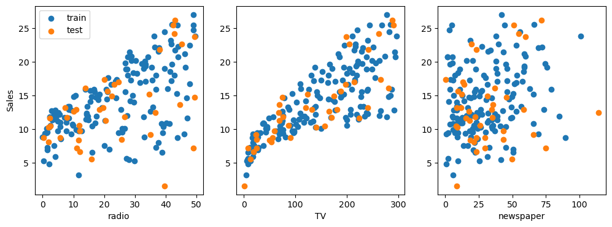

```python
plt.figure(figsize=(12,4))
plt.subplot(1,3,1)
plt.scatter(X_train[:,0],Y_train, label='train')
plt.scatter(X_test[:,0],Y_test, label='test')
plt.ylabel('Sales')
plt.xlabel('radio')
plt.legend();
plt.subplot(1,3,2)
plt.scatter(X_train[:,1],Y_train)
plt.scatter(X_test[:,1],Y_test)
plt.xlabel('TV')
plt.subplot(1,3,3)
plt.scatter(X_train[:,2],Y_train)
plt.scatter(X_test[:,2],Y_test)
plt.xlabel('newspaper');
```

```python
sklreg = linear_model.LinearRegression()
```

```python
sklreg.fit(X_train,Y_train)
```

```
LinearRegression()
```

```python
wsk = [sklreg.intercept_[0],sklreg.coef_[0][0],sklreg.coef_[0][1],sklreg.coef_[0][2]]
```

```python
wsk
```

```
[2.9948930304953283,
 0.19649703415540512,
 0.04458402011996426,
 -0.002781463981925969]
```

```python
score_train, score_test = sklreg.score(X_train,Y_train),sklreg.score(X_test,Y_test)
score_train, score_test
```

```
(0.9067114990146383, 0.8601145185017867)
```

The results obtained after normalization are as follows:

```python
# Using normalization
sklreg_norm = linear_model.LinearRegression()
scaler = MinMaxScaler()
X_train_norm = scaler.fit_transform(X_train)
X_test_norm = scaler.transform(X_test)
sklreg_norm.fit(X_train_norm,Y_train)
```

```
LinearRegression()
```

```python
score_train_norm, score_test_norm = sklreg_norm.score(X_train_norm,Y_train),sklreg_norm.score(X_test_norm,Y_test)
score_train_norm, score_test_norm
```

```
(0.9067114990146382, 0.8601145185017868)
```

The results obtained after standarization are as follows:

```python
# Using Standardization
from sklearn.preprocessing import StandardScaler
X_train_scaled = StandardScaler().fit_transform(X_train)
X_test_scaled = StandardScaler().fit_transform(X_test)
```

```python
sklreg.fit(X_train_scaled, Y_train)
```

```
LinearRegression()
```

```python
score_train_std, score_test_std = sklreg.score(X_train_scaled,Y_train),sklreg.score(X_test_scaled,Y_test)
score_train_std, score_test_std
```

```
(0.9067114990146383, 0.8281217233452881)
```

The results obtained after both normalization and standardization are used:

```python
sklreg_norm.fit(X_train_scaled, Y_train)
```

```
LinearRegression()
```

```python
score_train_norm_std, score_test_norm_std = sklreg_norm.score(X_train_scaled,Y_train),sklreg_norm.score(X_test_scaled,Y_test)
score_train_norm_std, score_test_norm_std
```

```
(0.9067114990146383, 0.8281217233452881)
```

When we compare all the results, we have:

```python
pd.DataFrame({'':['Original input','With normalization','With standarization','With normalization and standardization'],
              'Train score':[score_train,
                             score_train_norm,
                             score_train_std,
                             score_train_norm_std
                            ],
              'Test score':[score_test,
                             score_test_norm,
                             score_test_std,
                             score_test_norm_std
                           ] } )
```

|  |  | Train score | Test score |
| --- | --- | --- | --- |
| 0 | Original input | 0.906711 | 0.860115 |
| 1 | With normalization | 0.906711 | 0.860115 |
| 2 | With standarization | 0.906711 | 0.828122 |
| 3 | With normalization and standardization | 0.906711 | 0.828122 |

# Polynomial regression

**Polynomial regression** is a special case of linear regression. A multivariate regression of one variable ($x$), with a polynomial degree of 2 is:

$$ h_\theta(x) = \theta_0+\theta_1x+\theta_2x^2 $$

Now the hypothesis can be written as follows:

$$ h_\theta(x) = \theta_0+\theta_1x'_1+\theta_2x'_2 $$

This means that the polynomial regression can be treated as a normal linear regression by expanding the feature base. For example, if we have the following feature vector:

$$ X = \left[ \begin{matrix} 3\\ 5\\ 4\\ 2 \end{matrix} \right] $$

We can expand the feature set ($X$) by addding/creating a second column with the values of the features equal to the original features, to the power of two:

$$ X' = \left[ \begin{matrix} 3 & 9\\ 5 & 25\\ 4 & 16\\ 2 & 4 \end{matrix} \right] $$

Now we can use our linear regression process.

For multi-features and polynomial regression, the idea is the same. In the case of two features and quadratic polynomial regression, we have:

$$ h_\theta(x) = \theta_0+\theta_1x_1+\theta_2x_2+\theta_3x_1^2+\theta_4x_1x_2+\theta_5x_2^2, $$

which can be rewrritten in terms of expanded features:

$$ h_\theta(x) = \theta_0+\theta_1x'_1+\theta_2x'_2+\theta_3x'_3+\theta_4x'_4+\theta_5x'_5 $$

```python
# Simple function to generate points along a sine line
def gen_poly_samples(n, a=0.7, s=0.1, b=5):
    """
    n: Number of point to generate
    a: lines slope
    s: spread distance
    b: intercept with y axis
    """
    X = np.sort(np.random.rand(n))
    Y = np.sin(a * np.pi * X) + b + np.random.randn(n) * s
    return X.reshape(n,1),Y.reshape(n,1)
```

```python
X_train,Y_train = gen_poly_samples(50)
X_test,Y_test = gen_poly_samples(10)
```

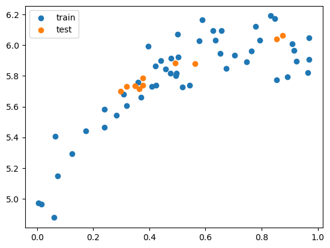

```python
plt.scatter(X_train, Y_train, label='train')
plt.scatter(X_test, Y_test, label='test')
plt.legend();
```

Given the previous set of data points, we create a linear regression model:

```python
sklreg = linear_model.LinearRegression()
sklreg.fit(X_train,Y_train)
Y_pred = sklreg.predict(X_train)
```

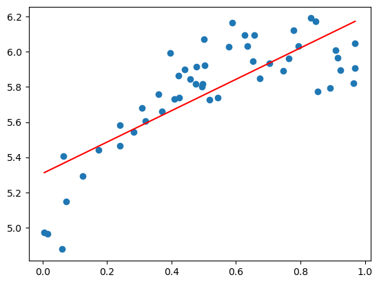

```python
plt.scatter(X_train,Y_train)
plt.plot(X_train,Y_pred,'r')
```

```python
sklreg.score(X_train,Y_train),sklreg.score(X_test,Y_test)
```

```
(0.6254739144817223, 0.34164883985439487)
```

```python
X_train
```

```
array([[0.00555553],
       [0.01550367],
       [0.05924572],
       [0.06448915],
       [0.07216317],
       [0.12534432],
       [0.17321057],
       [0.23931797],
       [0.24002824],
       [0.28259112],
       [0.30910235],
       [0.31908932],
       [0.35977203],
       [0.37059049],
       [0.39688572],
       [0.40967121],
       [0.42189369],
       [0.42420509],
       [0.44188742],
       [0.45756846],
       [0.47510849],
       [0.47780346],
       [0.49402668],
       [0.4970585 ],
       [0.49978041],
       [0.5027586 ],
       [0.51807402],
       [0.54374197],
       [0.57695848],
       [0.58916521],
       [0.62604627],
       [0.63460908],
       [0.65327969],
       [0.655795  ],
       [0.67324808],
       [0.70431464],
       [0.74761685],
       [0.76356182],
       [0.77860504],
       [0.79335569],
       [0.83216813],
       [0.84745561],
       [0.85338003],
       [0.89146167],
       [0.90888813],
       [0.91469014],
       [0.92396454],
       [0.9642169 ],
       [0.96853801],
       [0.96962304]])
```

Now, using polynomial regression to create a second model:

```python
from sklearn.preprocessing import PolynomialFeatures
```

```python
poly_features = PolynomialFeatures(degree=2)
```

```python
X_train_poly = poly_features.fit_transform(X_train)
```

```python
X_train_poly
```

```
array([[1.00000000e+00, 5.55553145e-03, 3.08639296e-05],
       [1.00000000e+00, 1.55036747e-02, 2.40363928e-04],
       [1.00000000e+00, 5.92457167e-02, 3.51005495e-03],
       [1.00000000e+00, 6.44891450e-02, 4.15884983e-03],
       [1.00000000e+00, 7.21631657e-02, 5.20752248e-03],
       [1.00000000e+00, 1.25344320e-01, 1.57111985e-02],
       [1.00000000e+00, 1.73210569e-01, 3.00019014e-02],
       [1.00000000e+00, 2.39317969e-01, 5.72730904e-02],
       [1.00000000e+00, 2.40028239e-01, 5.76135555e-02],
       [1.00000000e+00, 2.82591118e-01, 7.98577402e-02],
       [1.00000000e+00, 3.09102355e-01, 9.55442657e-02],
       [1.00000000e+00, 3.19089323e-01, 1.01817996e-01],
       [1.00000000e+00, 3.59772030e-01, 1.29435914e-01],
       [1.00000000e+00, 3.70590490e-01, 1.37337311e-01],
       [1.00000000e+00, 3.96885725e-01, 1.57518279e-01],
       [1.00000000e+00, 4.09671213e-01, 1.67830503e-01],
       [1.00000000e+00, 4.21893690e-01, 1.77994285e-01],
       [1.00000000e+00, 4.24205095e-01, 1.79949962e-01],
       [1.00000000e+00, 4.41887415e-01, 1.95264488e-01],
       [1.00000000e+00, 4.57568456e-01, 2.09368892e-01],
       [1.00000000e+00, 4.75108494e-01, 2.25728081e-01],
       [1.00000000e+00, 4.77803461e-01, 2.28296147e-01],
       [1.00000000e+00, 4.94026681e-01, 2.44062362e-01],
       [1.00000000e+00, 4.97058496e-01, 2.47067148e-01],
       [1.00000000e+00, 4.99780411e-01, 2.49780459e-01],
       [1.00000000e+00, 5.02758603e-01, 2.52766213e-01],
       [1.00000000e+00, 5.18074018e-01, 2.68400688e-01],
       [1.00000000e+00, 5.43741972e-01, 2.95655332e-01],
       [1.00000000e+00, 5.76958483e-01, 3.32881091e-01],
       [1.00000000e+00, 5.89165208e-01, 3.47115643e-01],
       [1.00000000e+00, 6.26046269e-01, 3.91933931e-01],
       [1.00000000e+00, 6.34609075e-01, 4.02728679e-01],
       [1.00000000e+00, 6.53279693e-01, 4.26774357e-01],
       [1.00000000e+00, 6.55794999e-01, 4.30067080e-01],
       [1.00000000e+00, 6.73248081e-01, 4.53262978e-01],
       [1.00000000e+00, 7.04314644e-01, 4.96059117e-01],
       [1.00000000e+00, 7.47616850e-01, 5.58930955e-01],
       [1.00000000e+00, 7.63561821e-01, 5.83026655e-01],
       [1.00000000e+00, 7.78605042e-01, 6.06225812e-01],
       [1.00000000e+00, 7.93355692e-01, 6.29413254e-01],
       [1.00000000e+00, 8.32168129e-01, 6.92503795e-01],
       [1.00000000e+00, 8.47455611e-01, 7.18181013e-01],
       [1.00000000e+00, 8.53380029e-01, 7.28257474e-01],
       [1.00000000e+00, 8.91461673e-01, 7.94703915e-01],
       [1.00000000e+00, 9.08888129e-01, 8.26077631e-01],
       [1.00000000e+00, 9.14690137e-01, 8.36658046e-01],
       [1.00000000e+00, 9.23964540e-01, 8.53710472e-01],
       [1.00000000e+00, 9.64216897e-01, 9.29714224e-01],
       [1.00000000e+00, 9.68538009e-01, 9.38065875e-01],
       [1.00000000e+00, 9.69623045e-01, 9.40168848e-01]])
```

```python
sklreg_poly = linear_model.LinearRegression()
sklreg_poly.fit(X_train_poly,Y_train)
```

```
LinearRegression()
```

```python
Xl = np.linspace(0, 1, 100).reshape(100,1)
```

```python
Xl_poly = poly_features.fit_transform(Xl)
```

```python
Y_pred = sklreg_poly.predict(Xl_poly)
```

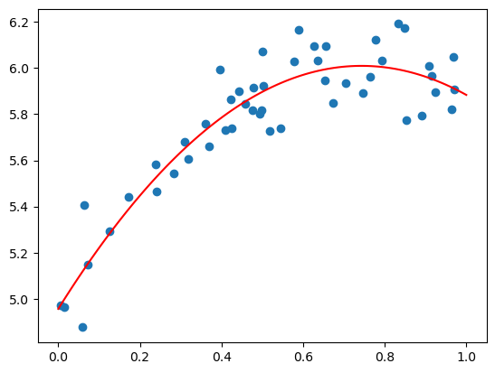

```python
plt.scatter(X_train,Y_train)
plt.plot(Xl,Y_pred,'r');
```

```python
sklreg_poly.score(X_train_poly,Y_train),sklreg_poly.score(poly_features.fit_transform(X_test),Y_test)
```

```
(0.8618456101229471, 0.8410804248470709)
```

As we can see, the polynomial regression produced better predictions than did the linear model.

## Exercise

✏️ Change the polynomial degree (e.g., 3,5,10) and compare the score results for training and testing data sets.

## Polynomial Degree

From the exercise, we found that using different polynomial degrees produces improvements or reductions in the model performance. To determine the right polynomial degree to use, we need to test the different possibilities and compare them. We will use Mean Square Error to measure the performance, considering the training and testing data.

```python
from sklearn.pipeline import Pipeline
from sklearn.preprocessing import PolynomialFeatures
from sklearn.linear_model import LinearRegression
from sklearn.model_selection import cross_val_score
from sklearn.metrics import mean_squared_error
```

This first version uses cross-validation (k-fold cross-validation) over the data points

```python
def compute_mse_cv(X, Y, n_degree=6):
    mse = []
    std = []
    for degree in range(1,n_degree):
        poly_features = PolynomialFeatures(degree=degree)
        sklreg = linear_model.LinearRegression()
        pipeline = Pipeline([("polynomial_features", poly_features),
                             ("linear_regression", sklreg)])
        pipeline.fit(X, Y)

        # Evaluate the models using crossvalidation
        scores = cross_val_score(pipeline, X, Y,
                                 scoring="neg_mean_squared_error",
                                 cv=10, error_score=np.nan)

        mse.append(-scores.mean())
        std.append(scores.std())
    return mse,std
```

```python
X_train,Y_train = gen_poly_samples(30)
```

```python
mse,std = compute_mse_cv(X_train,Y_train)
```

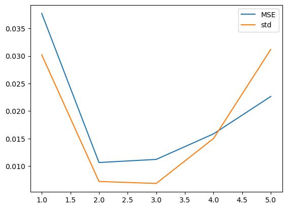

```python
plt.plot(range(1,len(mse)+1),mse, label='MSE')
plt.plot(range(1,len(std)+1),std, label='std')
plt.legend();
```

This second version uses separated sets for training and testing to compare how the performance changes for training data vs testing data

```python
def compute_mse(X_train, Y_train, X_test, Y_test, n_degree=11):
    train_mse = []
    test_mse = []
    for degree in range(1,n_degree):
        poly_features = PolynomialFeatures(degree=degree)
        sklreg = linear_model.LinearRegression()
        pipeline = Pipeline([("polynomial_features", poly_features),
                             ("linear_regression", sklreg)])
        pipeline.fit(X_train, Y_train)
        Y_train_pred = pipeline.predict(X_train)
        Y_test_pred = pipeline.predict(X_test)

        train_mse.append(mean_squared_error(Y_train, Y_train_pred))
        test_mse.append(mean_squared_error(Y_test, Y_test_pred))
    return train_mse,test_mse
```

```python
X_test,Y_test = gen_poly_samples(40)
train_mse,test_mse = compute_mse(X_train,Y_train,X_test,Y_test)
```

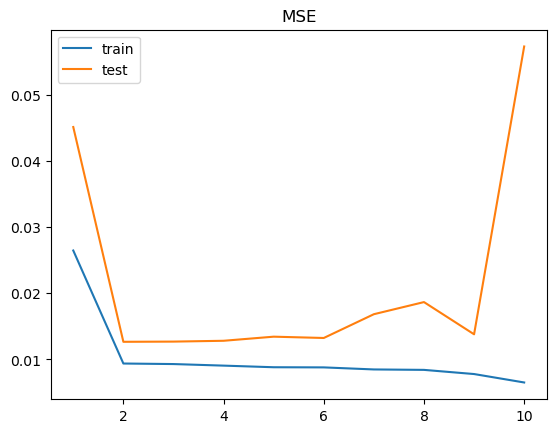

```python
plt.plot(range(1,len(train_mse)+1),train_mse, label='train')
plt.plot(range(1,len(test_mse)+1),test_mse, label='test')
plt.title('MSE')
plt.legend();
```

```python
print("Best degree: ",np.argmin(test_mse)+1)
```

```
Best degree:  2
```

To understand this behaviour, let us plot the predicted curves.

```python
def plot_models(X,Y,X_test, Y_test, degrees):
    for i,degree in enumerate(degrees):
        ax = plt.subplot(1, len(degrees), i + 1)
        poly_features = PolynomialFeatures(degree=degree)
        sklreg = linear_model.LinearRegression()
        pipeline = Pipeline([("polynomial_features", poly_features),
                             ("linear_regression", sklreg)])
        pipeline.fit(X,Y)
        Y_pred = pipeline.predict(X)
        plt.plot(X_test, pipeline.predict(X_test), label="Model")
        plt.scatter(X, Y, edgecolor='b', s=20, label="Samples")
        plt.scatter(X_test, Y_test, edgecolor='r',s=15, label="Test")
        plt.xlabel("x")
        plt.title("Degree {}".format(degree))
        plt.legend(loc="best")
```

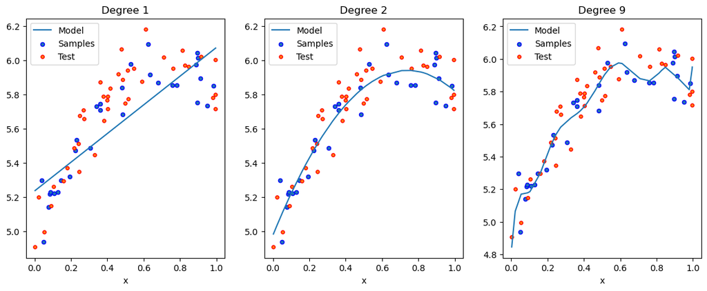

```python
plt.figure(figsize=(14, 5))
plot_models(X_train,Y_train,X_test,Y_test,[1,2,9])
```

The previous results show the problems of *underfitting* and *overfitting* that can be presented using linear regression with polynomial features to approximate nonlinear functions.

We call **underfitting** when the model is not sufficient to fit the training data (e.g., degree=1). On the other hand, when the model fits the training data too much, we call it **overfitting**.

# Feature selection

An important aspect that should be considered when we have multiple features is that not all the features contribute to the model's performance in the same way. Some features are more important than others. To determine which features are most significant, we can use the measures, F-test and p-value.

**F-test** estimates the degree of linear dependency between two random variables when comparing their variances. (See [The F-test for Linear Regression](http://facweb.cs.depaul.edu/sjost/csc423/documents/f-test-reg.htm) for an explanation how to calculate it.)

**p-value** is another measure that helps us determine the significance of each feature. It is used to validate or reject the **null hypothesis**. The null hypothesis ($H_0$) assumes that there is **no relationship** between a given input feature and the output. In the context of our model, it assumes that $\theta_i=0$ for $0 \leq i \le n$, where $n$ is the number of parameters. The meaning of the obtained p-values is as follows:

- a small p-value (typically < 0.05) indicates strong evidence against the null hypothesis. The null hypothesis is rejected;
- a large p-value (> 0.05) indicates weak evidence against the null hypothesis. The null hypothesis is NOT rejected.

p-value represents the probability that the coefficient is actually zero. (For more information about p-value.)

`scikit-learn` provides functions to compute F-test and p-value, as well asa function to remove the features with low significance.

```python
from sklearn.feature_selection import f_regression
```

```python
data = pd.read_csv('data/Advertising.csv')
X = data.loc[:,['radio','TV','newspaper']].values
Y = data['sales'].values
```

```python
from sklearn.preprocessing import PolynomialFeatures
poly_features = PolynomialFeatures(degree=2, include_bias=False)
X_poly = poly_features.fit_transform(X)
```

```python
F_test,p_value=f_regression(X_poly,Y)
pd.DataFrame({'feature':poly_features.get_feature_names_out(),
              'F_test':F_test,'p_value':p_value})
```

|  | feature | F_test | p_value |
| --- | --- | --- | --- |
| 0 | x0 | 98.421588 | 4.354966e-19 |
| 1 | x1 | 312.144994 | 1.467390e-42 |
| 2 | x2 | 10.887299 | 1.148196e-03 |
| 3 | x0^2 | 91.221485 | 5.094036e-18 |
| 4 | x0 x1 | 2597.227925 | 8.778003e-116 |
| 5 | x0 x2 | 41.409935 | 9.099688e-10 |
| 6 | x1^2 | 233.448111 | 2.491900e-35 |
| 7 | x1 x2 | 122.691160 | 1.680741e-22 |
| 8 | x2^2 | 9.646788 | 2.175199e-03 |

Using `SelectKBest`, we can reduce a number of features based on their significance.

```python
from sklearn.feature_selection import SelectKBest
```

```python
X_best = SelectKBest(f_regression,k=3).fit_transform(X_poly, Y)
```

```python
X_poly.shape, X_best.shape
```

```
((200, 9), (200, 3))
```

# Recap

In this section, we have presented how we can evaluate the develped model, using MSE and a score. We use linear regression to develop a model for multi-feature problems, we also have introduced polynomial regression. We have described two methods for feature scaling: normalization and standardization. An discussed how they affect training time. Finally, we have talked about F-test and p-value to learn more about which features are significant to the model developed.